# The Impact of Class Sizes on First Grade Math Scaled Scores

Ian Dimapasok

March 1, 2024

### 1. Abstract

This report delves into the Tennessee STAR project, exploring the effect class sizes have on 1st grade math scores. The dataset used in this study is introduced in the Background section, explaining what the data consists of and the experimental design used in the study. A descriptive analysis is then provided to show insightful summary statistics for various class types, which laid the ground work for a more deeper exploration. An ANOVA model and hypothesis testing is then employed to explore the effect of class types on the math scores of 1st grade students. Sensitivity analysis follows which assesses our model assumptions and employing various nonparametric tests when assumptions were violated. The report then explores other potential factors that impact the student achievement of 1st graders as well an analysis on the missing data and lastly, potential caveats in our analysis.

### 2. Introduction

In this project, we explore the impact of class size on educational outcomes, a topic of significant interest in the educational field. The motivation for this analysis is to understand the optimal class size for students in order to enhance student achievement and overall school performance. This study is particularly relevant for the Tennessee Student Teacher Achievement Ratio (STAR) experiment and other Class-Size Reduction (CSR) studies in various countries (Achilles et al, 2008). The potential impact of our results extends to informing educational policy, with implications for student achievement as well as teacher effectiveness.

### 3. Background

The Tennessee Student Teacher Achievement Ratio (STAR) experiment stands as a pivotal study in the field of early childhood education, specifically in the American K-12 education system. With its primary focus on the impact of class sizes on educational outcomes, STAR employed a rigorous experimental design, randomly assigning approximately 7,000 students each year to different class settings within 79 participating schools. The main features of this experiment are stated as below:

- The students were allocated into one of the three class types: “Small” class types with 15-17 students, “Regular” class types with 22-25 students, and “Regular with a full-time Aide” class types with also 22-25 students. (Achilles et al, 2008).
- Interventions were initiated as students entered school in kindergarten and this continued up until the third grade (Achilles et al, 2008).
- STAR enrollments were near 7,000 each year per grade level (Achilles et al, 2008).
- Schools from inner-city, rural, suburban, and urban locations were included in the study (Achilles et al, 2008).
- Students and teachers were randomly assigned to their class type (Achilles et al, 2008).

## 4. Descriptive analysis

### 4.1: Description of the Data

The STAR dataset consists of 11601 observations with 379 columns. These columns describe the background information of the students and teachers, the method of assigning class types, the identifiers for school and classes involved, and the academic test results. Our primary question of interest is to see whether there is any differences in math scaled scores in the first grade across all class types (small, regular, and regular with teacher aide). Our secondary question of interest is to see which class type is associated with the highest math scaled scores in the 1st grade. Because of this, we believe that the school identifier, 1st grade math scores, and class type are the most relevant factors for our questions of interest.

Before we explore the data, we first examined the dataset to see if there were any missing values. We found that there are about 4772 observations that are missing a class type. Because of this, we dropped all the observations in the data that do not have a class type. Furthermore, we dropped any observations that do not have a math score. There are a total of 5003 missing observations.

| Variable | Missing_Observations |
| --- | --- |
| Missing Observations in Class Type | 4772 |
| Missing Observations in Math Score | 5003 |
| Total Missing Observations | 5003 |

### 4.2: Exploratory Data Analysis

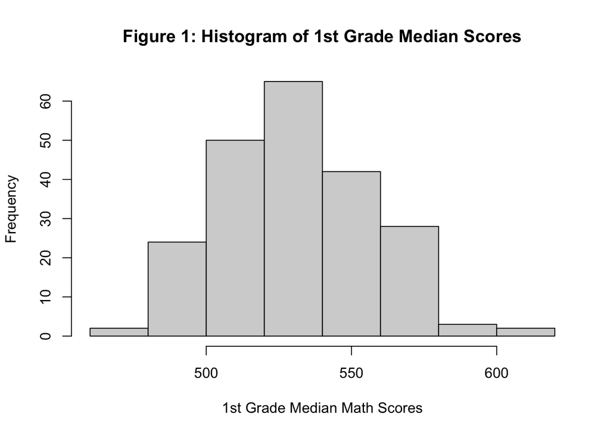

*Figure 1*: *Distribution of 1st Grade Math Scores by Median*

| Mean of 1st Grade Math Scores | 1st Grade Math Scores Standard Deviation of 1st Grade Math Scores | 1st Grade Math Scores Median of 1st Grade Math Scores | 1st Grade Math Scores 1st Quantile of 1st Grade Math Scores | 1st Grade Math Scores 3rd Quantile of 1st Grade Math Scores |
| --- | --- | --- | --- | --- |
| 530.5279 | 43.10868 | 529 | 500 | 557 |

Summary of Math Grades by Class Type

| Class Type | Average Math Grade | SD Math Grade | Median Math Grade | Q25 Math Grade | Q75 Math Grade |
| --- | --- | --- | --- | --- | --- |
| small | 538.6701 | 44.11365 | 535 | 508.5 | 567 |
| regular | 525.2744 | 41.65123 | 523 | 495.0 | 553 |
| regular + aide | 529.6147 | 42.87276 | 529 | 497.0 | 557 |

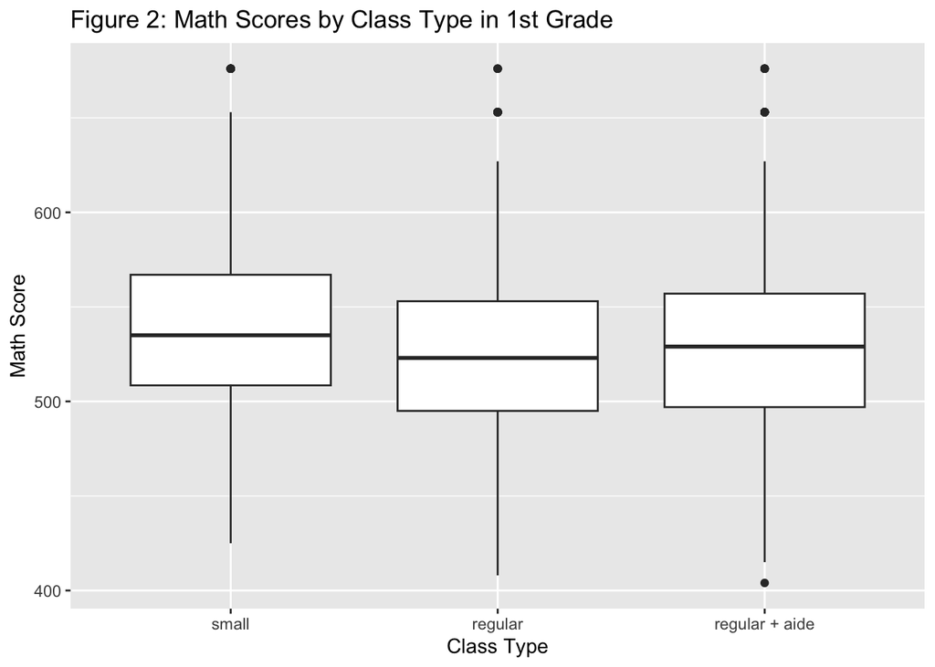

*Figure 2*: *1st Grade Math Scores by Class Type*

The data was aggregated by determining the median of the math scores from the first grade. We decided to aggregate the data by median rather than the mean due to the fact that the median measure provides a central location measure that is more representative of the typical math score than the mean. In addition, there are a few outliers in our data, and the presence of outliers can heavily influence the mean but will have much less impact on the median. Therefore, aggregating the data by median rather than mean would be a better fit for our analysis.

Additionally, upon examining the data, there are a few schools that do not have all three class types, specifically school ID 244728, 244796, 244736, and 244839. Therefore, we will drop the observations that do not have all 3 class types. Dropping these observations from our dataset ensures a fair and accurate comparison as well as ensuring that we have at least one class type per observation in each school.

## 5. Inferential analysis

Upon examining the student enrollment in the STAR program, we observe a noticeable inconsistency in the number of students across different schools. Because of this, our dataset is not balanced so we will consider fitting an unbalanced two-way ANOVA model with fixed effects.

### 5.1: Two-Way ANOVA Model

Our unbalanced two-way ANOVA model is defined as $Y_{ijk} = \mu + \alpha_i + \beta_j + \epsilon_{ijk}$. $Y_{ijk}$ is the outcome measure for the ith class type and jth school, $\mu$ is the overall mean of the outcome across all groups, $\alpha_i$ is the effect of the ith class type (small, regular, and regular w/ aide), $\beta_j$ is the effect of the jth school, and $\epsilon_{ijk}$ is the random error term for the observation of the ith class type and the jth school. For our two-way ANOVA model without interactions, we define the constraints to be $\sum_{i=1}^a \alpha_i = 0$ & $\sum_{j=1}^b \beta_j= 0$ and we assume that the error terms are normally distributed with mean 0 and variance $\sigma^2$.

### 5.2: Hypothesis Testing

Based on our primary question of interest, we will test to see if there is any differences in math scaled scores in 1st grade across class types. To test this, we define our null hypothesis to be $H_0$: all $\alpha_i$ = 0 for all i = 1,2,3 and our alternative hypothesis would be $H_a$: not all $\alpha_i$ = 0. Looking at the F-Table above, we get a test statistic of 17.899 and a p-value of 0.0000000117. Since our test statistic is high and our p-value is not greater than our significance level $\alpha = 0.05$, we will reject the null hypothesis. Therefore, we conclude that at the 5% significance level that there is a difference in math scaled scores in 1st grade across class types.

ANOVA Table for Two-Way ANOVA Model

|  | Sum Sq | Df | F value | Pr(>F) |
| --- | --- | --- | --- | --- |
| Class_Type | 8316.294 | 2 | 17.898577 | 1e-07 |
| School_ID | 96467.554 | 71 | 5.848461 | 0e+00 |
| Residuals | 32989.039 | 142 | NA | NA |

## 6. Sensitivity analysis

After running a two-way ANOVA model, we want to check if our model fits our assumptions well. Therefore, we need to test:

1. The residuals are normally distributed.
2. The residuals have equal variance.
3. The residuals are independent and identically distributed.

### 6.1: Normality Assumption

From `Figure 3`, we can see that most of the points follow the diagonal line. However, there are a few points that deviate away from the line. These points could violate our normality assumption so we will run a Shapiro-Wilks test to confirm whether our normality assumption has been violated.

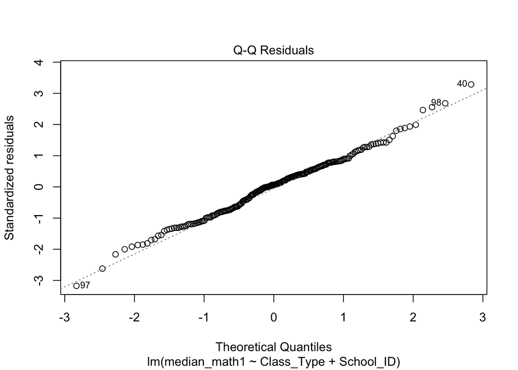

*Figure 3*: *Model Diagnostic Plot: Q-Q Plot*

Shapiro-Wilk Test Results

|  | Statistic | P_Value |
| --- | --- | --- |
| W | 0.9934025 | 0.452877 |

When carrying out our Shapiro-Wilks test we are testing whether our error terms follow a normal distribution. We define our null hypothesis to be $H_0$: The error terms are normally distributed, and our alternative hypothesis to be $H_a$: The error terms are not normally distributed. After running the Shapiro-Wilks test, we obtain a test statistic where W = 0.9934 and the p-value is 0.4529. Since our p-value is greater than our significance level $\alpha = 0.05$, we fail to reject the null hypothesis. Therefore, we can conclude that at the 5% significance level, that our error terms are normally distributed.

### 6.2: Equal Variance Assumption:

In order to visualize whether our equal variance assumption is met, we will take a look at our residual vs fitted plot to see if there are any discernible patterns in the plot. Looking at `Figure 4`, there are no discernible patterns in the residual vs fitted plot. This could mean that our equal variance assumption is met, but we will carry out a Levene-Test to confirm our suspicions.

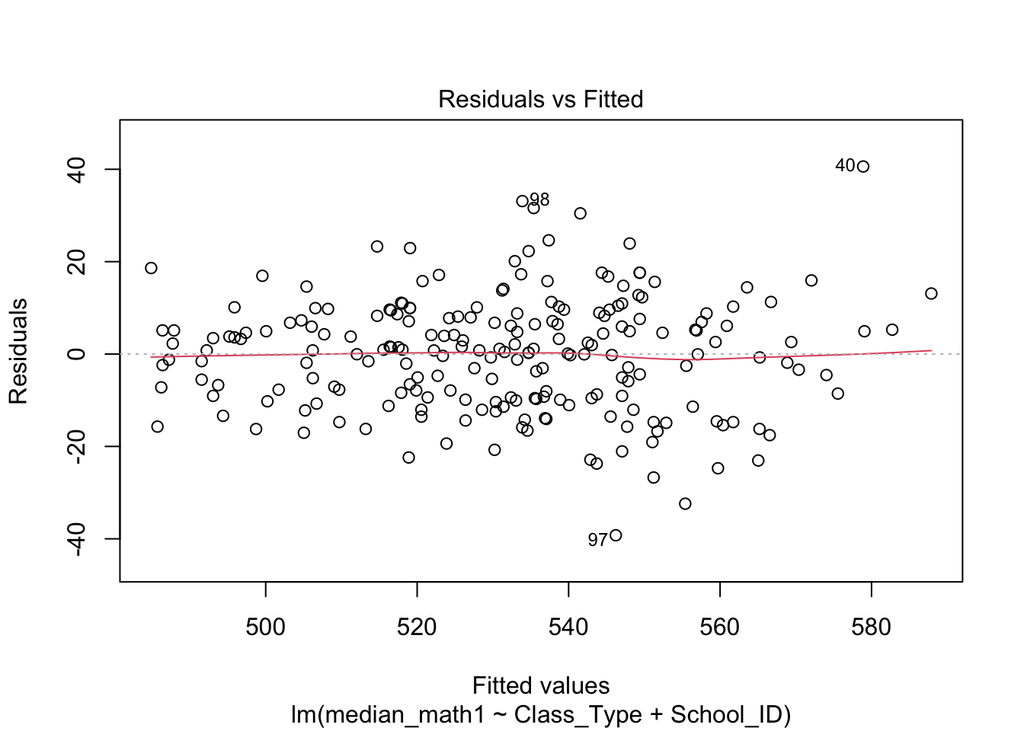

*Figure 4*: *Model Diagnostic Plot: Residual vs Fitted Plot*

We define our null hypothesis as $H_0$: The variances between each class type is equal and our alternative hypothesis to be $H_a$: At least one class type has a variance that is significantly different from the variances of the other class types. In addition, we our also testing the equal variance assumption for each school. We define our null hypothesis as $H_0$: The variances between each school is equal and our alternative hypothesis as $H_a$: At least one school has a variance that is significantly different from the variances of the other schools.

| Factor | Degrees_of_Freedom | Mean_Square | F_Value | P_Value |
| --- | --- | --- | --- | --- |
| Class Type | 2 | 77.00724 | 1.908105 | 0.1521459 |
| School ID | 71 | 88.43876 | 2.191358 | 0.0000385 |

### 6.3: Independence:

Based on the experimental design, we can assume independence of the error terms. This is because within each school, students and teachers were randomly assigned to different class types. Due to this, the experimental design ensured that high/low performing students or teachers did not enhance or diminish the performance of a certain class type.

### 6.4: Nonparametric Approach

Because the equal variance assumption was violated using a parametric test, we cannot use the F-Test or other normality based tests to test the effect between class types and 1st grade math scaled scores. Due to these violations, we employed a nonparametric test, specifically the Scheirer-Ray-Hare test. The Scheirer-Ray-Hare test is specifically used to test the differences between two or more factors and is an extension to the Kruskal-Wallis test. By using the Scheirer-Ray-Hare test, we are bypassing the need for normality or equal variances because the test is based on ranks rather than the actual data values. This test can be used to test whether the math scaled scores are affected by class types and different schools. We define our null hypothesis to be $H_0$ : The medians of 1st grade math scaled scores of all groups are equal and our alternative hypothesis as $H_a$: At least one group’s median of 1st grade math scaled scores differs from the others.

|  | Df | Sum Sq | H | p.value |
| --- | --- | --- | --- | --- |
| Class_Type | 2 | 39365.36 | 10.08711 | 0.0064508 |
| School_ID | 71 | 589405.17 | 151.03118 | 0.0000001 |
| Class_Type:School_ID | 142 | 210275.47 | 53.88170 | 1.0000000 |
| Residuals | 0 | 0.00 | NA | NA |

### 6.5: Multiple Comparison using Dunn Test

Because we found that there are significant differences within the groups, we will carry out with post-hoc tests (such as pairwise comparisons with a Dunn test) to determine which specific groups are different. Because we are specifically interested in testing if there are any differences in math scaled scores in the first grade across all class types, then we will run our Dunn test specifically on class type.

Multiple Comparison of Class Type (Bonferroni)

Comparison

Z

P

Significance

regular vs. regular w/ aide

0.153406

1.0000

regular vs. small

-2.670602

0.0114

regular w/ aide vs. small

-2.824008

0.0071

Based on the results of the Dunn test, we see that the test statistics for the comparison of small class types with regular and regular + aide class types are -2.670602 and -2.824008 respectively. In addition, the adjusted p-values for comparison between small class types are 0.0114 and 0.0071. This indicates that these p-values are statistically significant at the 0.05 significance level after adjusting for multiple comparisons using the Bonferroni method. The Dunn Test revealed that the median difference is between the small class type and the regular class types, but not between the two regular class types. Furthermore, the Dunn test revealed that smaller classes tend to have higher 1st grade math scores compared to regular and regular with aide class types.

## 7. Discussion

### 7.1: Exploring Other Factors

[figure not shown]

In addition, the 1st grade students attending schools in inner-city locations tend to have lower math scores in comparison to other locations. This observation is supported by the boxplots in `Figures 6 and 7` which highlight the lower median scores. Schools who had more than half of their students on the free or reduced lunch program were defined as inner-city schools according to the project description (Achilles et al, 2008). Because of this, the relationship between school location and student math scores suggests that socioeconomic factors play a role in a 1st grader’s academic performance. Inner-city schools, which often face challenges such as limited resources, higher student-to-teacher ratios, and less access to educational materials, may struggle to provide the same level of support as schools in more upscale areas. Despite this, smaller class sizes are still associated with higher 1st grade math scores, regardless of the school’s location. The impact of smaller class sizes on student performance is further confirmed by the results earlier in the report.

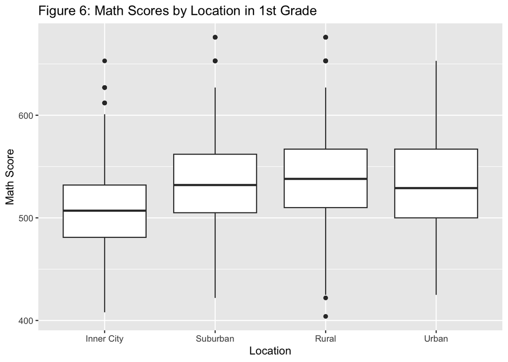

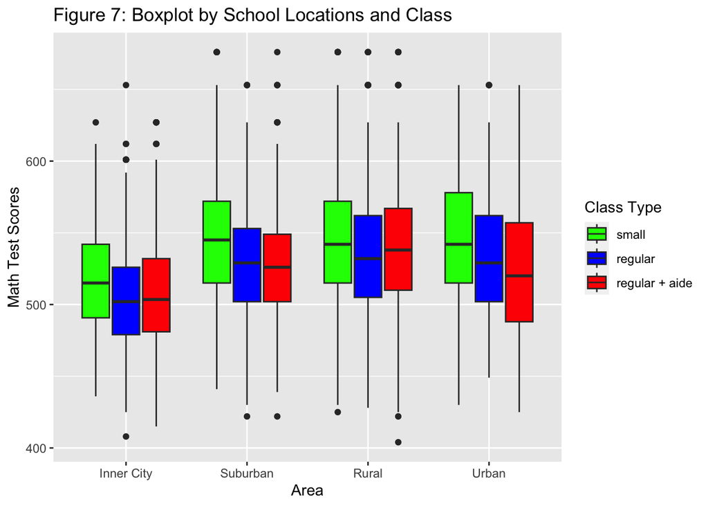

*Figure 6*: *Boxplot of 1st Grade Math Scores by Location*

*Figure 7*: *Boxplot of 1st Grade Math Scores by Class Type grouped by Location*

### Analysis on Missing Data

Before conducting our analysis on the STAR dataset, there were many missing values that had to be dropped from the dataset. Examining the missing values, there is a trend that suggests that students are either dropping out or enrolling into the STAR program every year, especially from kindergarten to 3rd grade, as stated in the Background section. This is especially prevalent for students going from kindergarten to 1st grade, showing a massive decreasing trend in missing values according to `Figure 8`. The significant shift highlights the importance of grades early in the STAR program and seems to be critical in terms of student retention and enrollment into the STAR program. Additionally, the missing values begin to steadily increase or decrease from 1st grade up to 3rd grade, but not as drastically as the transition from kindergarten to first grade. The missing data in the STAR dataset reveals important trends in student movement, especially during the early grades, and could have implications for evaluating the program’s effectiveness.

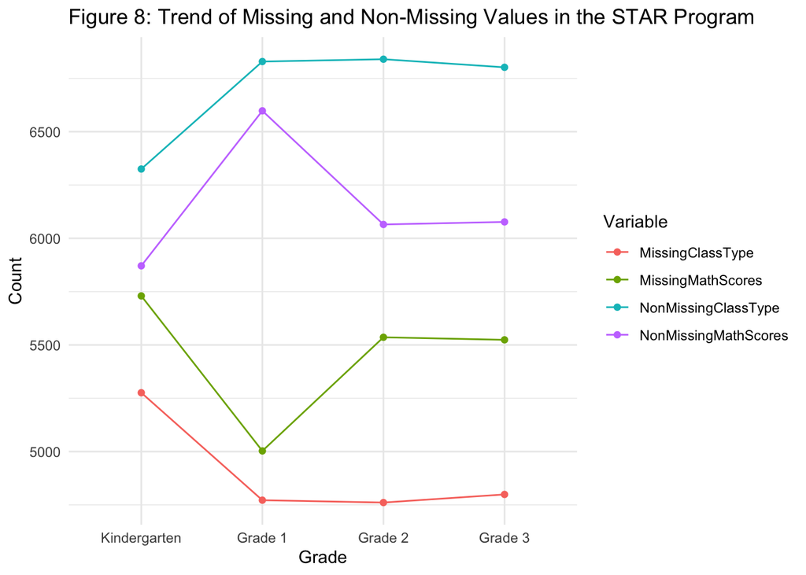

**Figure 8**: *Trend Plot of Missing and Non-Missing Values in the STAR Program*

### 7.3: Conclusions

Our analysis highlighted some challenges, including unequal variances in our ANOVA model and the various trends of missing data in our dataset. However, we observed several key findings related to the impact of class sizes on educational outcomes in early childhood education. One notable observation is the difference in median scores between first-grade math scores, where small classes tend to have higher averages compared to regular and regular with aide classes. This suggests that smaller class sizes may positively influence academic performance for students in early grades. Given these observations, policymakers should prioritize making investments in reducing class sizes, particularly in the early grades, in order to improve educational outcomes. Furthermore, policymakers should evaluate the allocation of resources, especially in inner-city locations to ensure that schools have the capacity to implement smaller classes without compromising the quality of education. Lastly, policies should also support professional development for teachers to effectively manage and teach in smaller class settings.

# Acknowledgement

1. Shizhe Chen, Chapter 4 ANOVA lecture notes was used to help fit the ANOVA model and define the ANOVA model.
2. Nonparametric techniques were discussed with Sara G. and Ben J. using Sara G’s STA 104 discussion notes.
3. Project was discussed with Sara G., Leena Q, and Ben J.

# Reference

1. Achilles, C. M. (2012, September 30). Class-size policy: The Star Experiment and related class-size studies. NCPEA policy brief. volume 1, Number 2. NCPEA Publications. https://eric.ed.gov/?id=ED540485
2. Achilles, C.M., Bain, H. P., Bellott, F., Boyd-Zaharias, J., Finn, J., Folger, J., Johnston, J., & Word, E. (2008, October 7). Tennessee’s student teacher achievement ratio (STAR) project. Harvard Dataverse. https://dataverse.harvard.edu/dataset.xhtml?persistentId=hdl%3A1902.1%2F10766
3. Meier, L. Chapter 6 random and mixed effects models: ANOVA and mixed models. Chapter 6 Random and Mixed Effects Models | ANOVA and Mixed Models. https://people.math.ethz.ch/~meier/teaching/anova/random-and-mixed-effects-models.html

## Appendix: all codes

```r
knitr::opts_chunk$set(fig.pos = 'H')
library(haven)
library(knitr)
library(dplyr)
library(kableExtra)
library(ggplot2)
library(car)
library(lme4)
library(rcompanion)
library(broom)
library(dunn.test)
library(gridExtra)
library(reshape2)
# Read in the STAR data set using the Haven package
STAR = read_sav("/Users/iandimapasok/Desktop/UC_Davis_Courses/STA 207/Project/STAR_students.sav")
# Identify missing data in the original dataset
missing_class_type = subset(STAR, is.na(g1classtype))
missing_math_score = subset(STAR, is.na(g1tmathss))

# Combine the observations with missing class type or math score
missing_data = unique(rbind(missing_class_type, missing_math_score))

# Create a summary data frame for the missing data
missing_summary = data.frame(
  Variable = c("Missing Observations in Class Type", "Missing Observations in Math Score",
               "Total Missing Observations"),
  Missing_Observations = c(nrow(missing_class_type), nrow(missing_math_score), nrow(missing_data)))

kable(missing_summary)
# Define a dataframe using only a few columns
STAR_reduced = STAR[c("g1schid", "g1tchid", "g1surban", "g1tmathss", "g1classtype", "g1freelunch")]

# Drop the null values in the dataset
# Make sure to drop the values that are not in STAR
STAR_reduced = STAR_reduced %>%
  filter(!is.na(g1classtype), !is.na(g1tmathss))

colnames(STAR_reduced) = c("School_ID", "Teacher_ID", "City_Type","Math_Scores_1st", "Class_Type", "Lunch_Program")

# Convert Class_Type, Teacher_ID, and School_ID column into a factor type variable
STAR_reduced$Class_Type = factor(STAR_reduced$Class_Type,
                               levels = c(1,2,3),
                               labels = c("small", "regular", "regular + aide"))
STAR_reduced$City_Type = factor(STAR_reduced$City_Type,
                               levels = c(1,2,3,4),
                               labels = c("Inner City", "Suburban", "Rural", "Urban"))
STAR_reduced$Class_Type = as.factor(STAR_reduced$Class_Type)
STAR_reduced$Teacher_ID = as.factor(STAR_reduced$Teacher_ID)
STAR_reduced$School_ID = as.factor(STAR_reduced$School_ID)
STAR_reduced$City_Type = as.factor(STAR_reduced$City_Type)
STAR_reduced$Lunch_Program = as.factor(STAR_reduced$Lunch_Program)
# Aggregate the data by median
aggregated_data_median = STAR_reduced %>%
  group_by(School_ID, Class_Type, City_Type) %>%
  summarise(median_math1 = median(Math_Scores_1st, na.rm = TRUE, .groups = 'drop')) %>%
  ungroup()

# Drop the schools that don't have at least one of each class type
drop_school_id = c(244728, 244796, 244736, 244839)
aggregated_data_median = aggregated_data_median[!(aggregated_data_median$School_ID
                                               %in% drop_school_id),]

aggregated_data_median$School_ID = droplevels(aggregated_data_median$School_ID)
aggregated_data_median$Class_Type = droplevels(aggregated_data_median$Class_Type)

hist(aggregated_data_median$median_math1, main = "Figure 1: Histogram of 1st Grade Median Scores",
     xlab = "1st Grade Median Math Scores")
# Summary of overall math scores
summary_math_scores = STAR_reduced %>%
  summarise(
    avg_math_grade1 = mean(Math_Scores_1st, na.rm = TRUE),
    sd_math_grade1 = sd(Math_Scores_1st, na.rm = TRUE),
    median_math_grade1 = median(Math_Scores_1st, na.rm = TRUE),
    q25_math_grade1 = quantile(Math_Scores_1st, 0.25, na.rm = TRUE),
    q75_math_grade1 = quantile(Math_Scores_1st, 0.75, na.rm = TRUE)
    )

# Change the column names of the table
colnames(summary_math_scores) = c("Mean of 1st Grade Math Scores",
                                  "Standard Deviation of 1st Grade Math Scores",
                                  "Median of 1st Grade Math Scores",
                                  "1st Quantile of 1st Grade Math Scores",
                                  "3rd Quantile of 1st Grade Math Scores")
# Display the table using kable
kable(summary_math_scores, format = "html", booktabs = TRUE) %>%
  kable_styling(bootstrap_options = c("striped", "hover", "condensed"), full_width = F, position = "left") %>%
  column_spec(1, bold = TRUE) %>%
  add_header_above(c(" " = 1, "1st Grade Math Scores" = 4))
# Generate summary statistics for 1st grade math scores based on class type.
summary_class_types = STAR_reduced %>%
  group_by(Class_Type) %>%
  summarise(
    avg_math_grade1 = mean(Math_Scores_1st, na.rm = TRUE),
    sd_math_grade1 = sd(Math_Scores_1st, na.rm = TRUE),
    median_math_grade1 = median(Math_Scores_1st, na.rm = TRUE),
    q25_math_grade1 = quantile(Math_Scores_1st, 0.25, na.rm = TRUE),
    q75_math_grade1 = quantile(Math_Scores_1st, 0.75, na.rm = TRUE)
  )
# Rename the columns of the summary_class_types data frame
colnames(summary_class_types) = c("Class Type", "Average Math Grade", "SD Math Grade", "Median Math Grade", "Q25 Math Grade", "Q75 Math Grade")

# Print it out as a table
kable(summary_class_types, caption = "Summary of Math Grades by Class Type")

# Plotting for math scores for 1st graders by class types
ggplot(STAR_reduced, aes(x = factor(Class_Type), y = Math_Scores_1st)) +
  geom_boxplot() +
  labs(title = "Figure 2: Math Scores by Class Type in 1st Grade", x = "Class Type", y = "Math Score")
# Running a balanced two-way ANOVA model with no interaction
# excluded_rows = c("31", "40", "98")
unbalanced_aov = Anova(lm(median_math1 ~ Class_Type + School_ID, data = aggregated_data_median), type = 2)
                     # subset=setdiff(rownames(aggregated_data_median), excluded_rows)
kable(unbalanced_aov, caption = "ANOVA Table for Two-Way ANOVA Model", "html") %>%
  kable_styling(full_width = FALSE, position = "left") %>%
  column_spec(1, border_right = TRUE) %>%
  column_spec(2, border_right = TRUE)
# Check the assumptions of the balanced anova model to see whether assumptions are met
lm_fit = lm(median_math1 ~ Class_Type + School_ID, data = aggregated_data_median)
plot(lm_fit, which = 2)
# Conduct a Shapiro-Wilks Test to test our normality assumption
Shapiro = shapiro.test(residuals(lm_fit))
Shapiro_result = data.frame(Statistic = Shapiro$statistic, P_Value = Shapiro$p.value)
kable(Shapiro_result, caption = "Shapiro-Wilk Test Results", "html") %>%
  kable_styling(full_width = FALSE, position = "left") %>%
  column_spec(1, border_right = TRUE) %>%
  column_spec(2, border_right = TRUE)
# Check the assumptions of the balanced anova model to see whether assumptions are met
plot(lm_fit, which = 1)
# Conduct the Levene Test for both factors
levene_test = summary(aov(abs(lm_fit$residuals) ~ Class_Type + School_ID, data = aggregated_data_median))
```

```r
# Extract relevant values
df_class_type = levene_test[[1]]["Class_Type", "Df"]
df_school_id = levene_test[[1]]["School_ID", "Df"]
mean_sq_class_type = levene_test[[1]]["Class_Type", "Mean Sq"]
mean_sq_school_id = levene_test[[1]]["School_ID", "Mean Sq"]
f_value_class_type = levene_test[[1]]["Class_Type", "F value"]
f_value_school_id = levene_test[[1]]["School_ID", "F value"]
p_value_class_type = levene_test[[1]]["Class_Type", "Pr(>F)"]
p_value_school_id = levene_test[[1]]["School_ID", "Pr(>F)"]

# Create a data frame
levene_results_df = data.frame(
  Factor = c("Class Type", "School ID"),
  Degrees_of_Freedom = c(df_class_type, df_school_id),
  Mean_Square = c(mean_sq_class_type, mean_sq_school_id),
  F_Value = c(f_value_class_type, f_value_school_id),
  P_Value = c(p_value_class_type, p_value_school_id)
)

kable(levene_results_df, "html") %>%
  kable_styling(full_width = FALSE, position = "left") %>%
  column_spec(1, border_right = TRUE) %>%
  column_spec(2, border_right = TRUE)
# Using Scheirer-Ray-Hare Test since this is a two-way ANOVA model
scheirer_test = scheirerRayHare(median_math1 ~ Class_Type + School_ID, data = aggregated_data_median)
# Table for the Scheirer-Ray-Hare test
kable(scheirer_test, "html") %>%
  kable_styling(full_width = FALSE, position = "left") %>%
  column_spec(1, border_right = TRUE) %>%
  column_spec(2, border_right = TRUE)
# Conduct a Dunn test for mulitple comparison
dunn_test_result = dunn.test(aggregated_data_median$median_math1, aggregated_data_median$Class_Type,
                             method="bonferroni")
# Create a data frame with Dunn test results
dunn_results = data.frame(
  Comparison = c("regular vs. regular w/ aide", "regular vs. small", "regular w/ aide vs. small"),
  Z = c(0.153406, -2.670602, -2.824008),
  P = c(1.0000, 0.0114, 0.0071),
  Significance = c("", "*", "*")
)

# Use kable to create a table
kable(dunn_results, caption = "Multiple Comparison of Class Type (Bonferroni)", format = "html") %>%
  kable_styling(bootstrap_options = c("striped", "hover"))
# Summarize the data to get the count of schools in each location
school_count = STAR_reduced %>%
  group_by(City_Type) %>%
  summarise(count = n())

# Create the bar graph
plot5 = ggplot(school_count, aes(x = City_Type, y = count, fill = City_Type)) +
  geom_bar(stat = "identity") +
  theme_minimal() +
  labs(
    title = "Figure 5: Number of Schools in Each Location",
    x = "Location",
    y = "Number of Schools"
  ) +
  scale_fill_manual(values = c("Inner City" = 'blue', "Rural" = "red", "Suburban" = "green", "Urban" = "brown"))
plot5
# Plotting for math scores for 1st graders by location
plot6 = ggplot(STAR_reduced, aes(x = factor(City_Type), y = Math_Scores_1st)) +
  geom_boxplot() +
  labs(title = "Figure 6: Math Scores by Location in 1st Grade", x = "Location", y = "Math Score")

# Generating a boxplot looking at the class types with math scores.
plot7 = ggplot(STAR_reduced, aes(x=City_Type, y=Math_Scores_1st, fill=Class_Type)) + geom_boxplot()+
        labs(title = "Figure 7: Boxplot by School Locations and Class ",
             x="Area", y = "Math Test Scores")+
        guides(fill=guide_legend(title="Class Type"))+
        scale_fill_manual(values=c("green", "blue", "red"))
plot6
plot7
# Create a data frame for the trend of missing values
missing_value_data = STAR[, c("gkclasstype", "g1classtype", "g2classtype", "g3classtype",
                              "gktmathss", "g1tmathss", "g2tmathss","g3tmathss",
                              "gkschid","g1schid", "g2schid", "g3schid")]

# Calculate missing values
missing_trend = data.frame(
  Year = c("Kindergarten", "Grade 1", "Grade 2", "Grade 3"),
  MissingClassType = c(sum(is.na(missing_value_data$gkclasstype)),
                       sum(is.na(missing_value_data$g1classtype)),
                       sum(is.na(missing_value_data$g2classtype)),
                       sum(is.na(missing_value_data$g3classtype))),
  MissingMathScores = c(sum(is.na(missing_value_data$gktmathss)),
                        sum(is.na(missing_value_data$g1tmathss)),
                        sum(is.na(missing_value_data$g2tmathss)),
                        sum(is.na(missing_value_data$g3tmathss)))
)


# Calculate non-missing values
non_missing_trend = data.frame(
  Year = c("Kindergarten", "Grade 1", "Grade 2", "Grade 3"),
  NonMissingClassType = c(sum(!is.na(missing_value_data$gkclasstype)),
                          sum(!is.na(missing_value_data$g1classtype)),
                          sum(!is.na(missing_value_data$g2classtype)),
                          sum(!is.na(missing_value_data$g3classtype))),
  NonMissingMathScores = c(sum(!is.na(missing_value_data$gktmathss)),
                           sum(!is.na(missing_value_data$g1tmathss)),
                           sum(!is.na(missing_value_data$g2tmathss)),
                           sum(!is.na(missing_value_data$g3tmathss)))
)

#Combine missing and non-missing data
combined_trend = cbind(missing_trend, non_missing_trend[, -1])

# Set the factor levels for 'Year' to ensure the correct order
combined_trend$Year = factor(combined_trend$Year, levels = c("Kindergarten", "Grade 1", "Grade 2", "Grade 3"))

# Melt the combined data for plotting
combined_trend_melted = melt(combined_trend, id.vars = "Year")

# Plot the line graph with lines for missing and non-missing values
ggplot(combined_trend_melted, aes(x = Year, y = value, group = variable, color = variable)) +
  geom_line() +
  geom_point() +
  labs(x = "Grade", y = "Count", title = "Figure 8: Trend of Missing and Non-Missing Values in the STAR Program",
       color = "Variable") +
  theme_minimal()
sessionInfo()
```